# Prediction Assignment Writeup

LLW

3 October 2017

## Background

Using devices such as Jawbone Up, Nike FuelBand, and Fitbit it is now possible to collect a large amount of data about personal activity relatively inexpensively. These type of devices are part of the quantified self movement - a group of enthusiasts who take measurements about themselves regularly to improve their health, to find patterns in their behavior, or because they are tech geeks. One thing that people regularly do is quantify how much of a particular activity they do, but they rarely quantify how well they do it. In this project, your goal will be to use data from accelerometers on the belt, forearm, arm, and dumbell of 6 participants. They were asked to perform barbell lifts correctly and incorrectly in 5 different ways.

Data Source: http://web.archive.org/web/20161224072740/http:/groupware.les.inf.puc-rio.br/har

### Loading Data

```r
# Reading in data while setting values with #DIV/0! as missing values
training = read.csv("pml-training.csv", na.strings=c("#DIV/0!"), header = TRUE)
testing = read.csv("pml-testing.csv", na.strings=c("#DIV/0!"), header = TRUE)

# Loading required R packages
library(caret)
```

```r
library(ggplot2)
library(randomForest)
library(e1071)
library(gbm)
```

### Preprocessing Data

```r
# Obtain a subset of the training set from the 6th to the last column
training <- training[, 6:dim(training)[2]]

#Remove columns with more than 95% of NA or "" values
threshold <- dim(training)[1] * 0.95
goodColumns <- !apply(training, 2, function(x) sum(is.na(x)) > threshold  || sum(x=="") > threshold)
training <- training[, goodColumns]

#Excluding near zero covariates in Training Set
zeroCov <- nearZeroVar(training,saveMetrics = TRUE)
training <- training[,zeroCov$nzv==FALSE]
training$classe = factor(training$classe)
```

### Performing Prediction Study Design

```r
#Partition the training set into training and validation set
inTrain <- createDataPartition(training$classe, p = 0.6)[[1]]
validation <- training[-inTrain,]
training <- training[ inTrain,]
inTrain <- createDataPartition(validation$classe, p = 0.75)[[1]]
validation_test <- validation[ -inTrain,]
validation <- validation[inTrain,]

testing <- testing[, 6:dim(testing)[2]]
testing <- testing[, goodColumns]
testing$classe <- NA

#Excluding near zero covariates in Testing Set
testing <- testing[, zeroCov$nzv==FALSE]
```

### Model Train

In this assignment, I will use Random Forest as the model.

```r
mod1 <- train(classe ~ ., method="rf", data=training, trControl = trainControl (method="cv"),number=3)
```

### Model Validation

```r
predVal <- predict(mod1, validation)

#Compute Confusion Matrix
cfmVal <- confusionMatrix(predVal, validation$classe)
print(cfmVal)
```

```
## Confusion Matrix and Statistics
##
##           Reference
## Prediction    A    B    C    D    E
##          A 1673    4    0    0    0
##          B    1 1133    0    0    0
##          C    0    1 1026    6    0
##          D    0    1    0  958    4
##          E    0    0    0    1 1078
##
## Overall Statistics
##
##                Accuracy : 0.9969
##                  95% CI : (0.9952, 0.9982)
##     No Information Rate : 0.2844
##     P-Value [Acc > NIR] : < 2.2e-16
##
##                   Kappa : 0.9961
##  Mcnemar's Test P-Value : NA
##
## Statistics by Class:
##
##                      Class: A Class: B Class: C Class: D Class: E
## Sensitivity            0.9994   0.9947   1.0000   0.9927   0.9963
## Specificity            0.9991   0.9998   0.9986   0.9990   0.9998
## Pos Pred Value         0.9976   0.9991   0.9932   0.9948   0.9991
## Neg Pred Value         0.9998   0.9987   1.0000   0.9986   0.9992
## Prevalence             0.2844   0.1935   0.1743   0.1639   0.1838
## Detection Rate         0.2842   0.1925   0.1743   0.1628   0.1831
## Detection Prevalence   0.2849   0.1927   0.1755   0.1636   0.1833
## Balanced Accuracy      0.9992   0.9973   0.9993   0.9959   0.9980
```

Given that the cross validation accuracy is 99.6%, it appears that the model is reasonably good. But we would still need to do the test on the validation test set to check if there is element of overfitting present.

### Test Set Prediction

```r
#Out-of-sample error
predTest <- predict(mod1, validation_test)
accuracy <- sum(predTest == validation_test$classe) / length(predTest)
print(accuracy)
```

```
## [1] 0.9969388
```

Again, this model achieved a 99.6% accuracy on the validation test set. Therefore, the Random Forest method worked rather well. Lastly, I will plot the top 15 most important variables for referencing.

Obtain Top 15 Most Important Variables

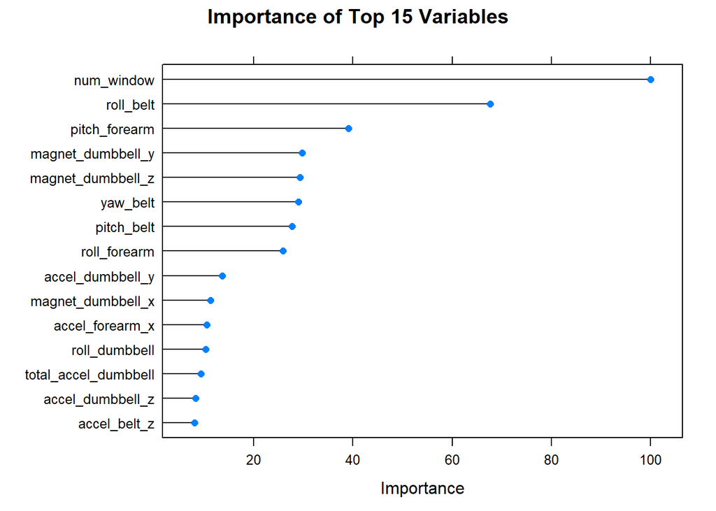

```r
varImpRF <- train(classe ~ ., data = training, method = "rf")
varImpObj <- varImp(varImpRF)
plot(varImpObj, main = "Importance of Top 15 Variables", top = 15)
```